# shl_players_eda

```r
remove(list = ls()) #Clearing environment
```

Loading the packeges I need.

```r
library(dplyr)
library(ggplot2)
library(ggthemes)
library(cowplot)
library(splitstackshape)
library(xtable)
```

```r
df <- read.csv('players.csv', encoding = 'UTF-8')
```

```r
head(df)
```

|  | nr | spelare | pos | gp | g | a | tp | pim | gwg | ppg | sog | hits | bks | X. | X..1 | X... | toi.gp | team |
| --- | --- | --- | --- | --- | --- | --- | --- | --- | --- | --- | --- | --- | --- | --- | --- | --- | --- | --- |
| 1 | 67 | *Leon Bristedt*L Bristedt | F | 46 | 14 | 32 | 46 | 78 | 2 | 4 | 93 | 33 | 22 | 43 | 24 | 19 | 17:04 | Rögle BK |
| 2 | 91 | Adam TambelliniA Tambellini | F | 39 | 24 | 19 | 43 | 6 | 5 | 11 | 135 | 14 | 9 | 42 | 18 | 24 | 17:56 | Rögle BK |
| 3 | 28 | Anton BengtssonA Bengtsson | F | 49 | 20 | 19 | 39 | 10 | 4 | 3 | 100 | 69 | 12 | 43 | 23 | 20 | 18:42 | Rögle BK |
| 4 | 16 | *Lucas Ekeståhl-Jonsson*L Ekeståhl-Jonsson | D | 52 | 7 | 29 | 36 | 20 | 2 | 4 | 93 | 18 | 45 | 44 | 35 | 9 | 20:36 | Rögle BK |
| 5 | 18 | Dennis EverbergD Everberg | F | 45 | 16 | 18 | 34 | 49 | 2 | 4 | 79 | 37 | 15 | 48 | 25 | 23 | 18:27 | Rögle BK |
| 6 | 12 | Brady FergusonB Ferguson | F | 52 | 6 | 17 | 23 | 18 | 2 | 0 | 74 | 18 | 27 | 37 | 25 | 12 | 17:53 | Rögle BK |

Columns X. X..1 X… and toi.gp has the wrong names, time to rename them.

```r
df[,'+'] <- df$X.
df[,'-'] <- df$X..1
df[,'+/-'] <- df$X...
df[,'toi/gp'] <- df$toi.gp

df$X. <- NULL
df$X..1 <- NULL
df$X... <- NULL
df$toi.gp <- NULL
```

```r
summary(df)
```

```
       nr          spelare              pos                  gp              g
 Min.   : 2.00   Length:448         Length:448         Min.   : 1.00   Min.   : 0.000
 1st Qu.:15.00   Class :character   Class :character   1st Qu.:13.75   1st Qu.: 0.000
 Median :27.00   Mode  :character   Mode  :character   Median :39.00   Median : 3.000
 Mean   :34.42                                         Mean   :32.06   Mean   : 4.507
 3rd Qu.:51.00                                         3rd Qu.:49.00   3rd Qu.: 7.000
 Max.   :98.00                                         Max.   :52.00   Max.   :34.000
 NA's   :2
       a                tp             pim             gwg              ppg
 Min.   : 0.000   Min.   : 0.00   Min.   : 0.00   Min.   :0.0000   Min.   : 0.000
 1st Qu.: 1.000   1st Qu.: 1.00   1st Qu.: 2.00   1st Qu.:0.0000   1st Qu.: 0.000
 Median : 5.000   Median : 8.00   Median : 8.00   Median :0.0000   Median : 0.000
 Mean   : 7.504   Mean   :12.01   Mean   :12.73   Mean   :0.8125   Mean   : 1.029
 3rd Qu.:11.250   3rd Qu.:18.00   3rd Qu.:18.00   3rd Qu.:1.0000   3rd Qu.: 1.000
 Max.   :53.000   Max.   :66.00   Max.   :78.00   Max.   :8.0000   Max.   :14.000

      sog              hits             bks            team                 +
 Min.   :  0.00   Min.   :  0.00   Min.   : 0.00   Length:448         Min.   : 0.00
 1st Qu.: 11.00   1st Qu.:  3.00   1st Qu.: 4.00   Class :character   1st Qu.: 3.00
 Median : 36.00   Median : 10.00   Median :14.00   Mode  :character   Median :15.00
 Mean   : 44.85   Mean   : 15.91   Mean   :16.54                      Mean   :16.62
 3rd Qu.: 69.25   3rd Qu.: 22.00   3rd Qu.:25.00                      3rd Qu.:27.00
 Max.   :203.00   Max.   :135.00   Max.   :76.00                      Max.   :55.00

       -              +/-              toi/gp
 Min.   : 0.00   Min.   :-23.0000   Length:448
 1st Qu.: 5.00   1st Qu.: -4.0000   Class :character
 Median :16.00   Median :  0.0000   Mode  :character
 Mean   :16.89   Mean   : -0.2679
 3rd Qu.:26.00   3rd Qu.:  3.0000
 Max.   :63.00   Max.   : 26.0000
```

```r
sum(is.na(df))
```

```
[1] 2
```

There are two players that doesnt have a jersey number, which is fine.

```r
str(df)
```

```
'data.frame':   448 obs. of  18 variables:
 $ nr     : num  67 91 28 16 18 12 54 40 61 6 ...
 $ spelare: chr  "*Leon Bristedt*L Bristedt" "Adam TambelliniA Tambellini" "Anton BengtssonA Bengtsson" "*Lucas Ekeståhl-Jonsson*L Ekeståhl-Jonsson" ...
 $ pos    : chr  "F" "F" "F" "D" ...
 $ gp     : int  46 39 49 52 45 52 47 47 50 45 ...
 $ g      : int  14 24 20 7 16 6 4 8 8 6 ...
 $ a      : int  32 19 19 29 18 17 15 10 9 10 ...
 $ tp     : int  46 43 39 36 34 23 19 18 17 16 ...
 $ pim    : int  78 6 10 20 49 18 6 4 14 20 ...
 $ gwg    : int  2 5 4 2 2 2 0 1 3 0 ...
 $ ppg    : int  4 11 3 4 4 0 0 1 1 0 ...
 $ sog    : int  93 135 100 93 79 74 46 70 58 69 ...
 $ hits   : int  33 14 69 18 37 18 36 8 28 59 ...
 $ bks    : int  22 9 12 45 15 27 33 14 19 37 ...
 $ team   : chr  "Rögle BK" "Rögle BK" "Rögle BK" "Rögle BK" ...
 $ +      : int  43 42 43 44 48 37 31 18 26 36 ...
 $ -      : int  24 18 23 35 25 25 26 22 17 21 ...
 $ +/-    : int  19 24 20 9 23 12 5 -4 9 15 ...
 $ toi/gp : chr  "17:04" "17:56" "18:42" "20:36" ...
```

Making a new columns that shows time on ice per games played in seconds

```r
df$min <- as.numeric(gsub(':.*', '', df$`toi/gp`)) #Extracting hours played
df$sec <- as.numeric(gsub('.*:', '', df$`toi/gp`)) #Extracting minutes played

df$toi_pgp_s <- df$min*60+df$sec #Combining them into one column that shows total seconds
#The players spent on ice per games played.

#Removing the columns i dont need anymore.
df$min <- NULL
df$sec <- NULL
df$`toi/gp`<- NULL
```

```r
str(df)
```

```
'data.frame':   448 obs. of  18 variables:
 $ nr       : num  67 91 28 16 18 12 54 40 61 6 ...
 $ spelare  : chr  "*Leon Bristedt*L Bristedt" "Adam TambelliniA Tambellini" "Anton BengtssonA Bengtsson" "*Lucas Ekeståhl-Jonsson*L Ekeståhl-Jonsson" ...
 $ pos      : chr  "F" "F" "F" "D" ...
 $ gp       : int  46 39 49 52 45 52 47 47 50 45 ...
 $ g        : int  14 24 20 7 16 6 4 8 8 6 ...
 $ a        : int  32 19 19 29 18 17 15 10 9 10 ...
 $ tp       : int  46 43 39 36 34 23 19 18 17 16 ...
 $ pim      : int  78 6 10 20 49 18 6 4 14 20 ...
 $ gwg      : int  2 5 4 2 2 2 0 1 3 0 ...
 $ ppg      : int  4 11 3 4 4 0 0 1 1 0 ...
 $ sog      : int  93 135 100 93 79 74 46 70 58 69 ...
 $ hits     : int  33 14 69 18 37 18 36 8 28 59 ...
 $ bks      : int  22 9 12 45 15 27 33 14 19 37 ...
 $ team     : chr  "Rögle BK" "Rögle BK" "Rögle BK" "Rögle BK" ...
 $ +        : int  43 42 43 44 48 37 31 18 26 36 ...
 $ -        : int  24 18 23 35 25 25 26 22 17 21 ...
 $ +/-      : int  19 24 20 9 23 12 5 -4 9 15 ...
 $ toi_pgp_s: num  1024 1076 1122 1236 1107 ...
```

Now I will make team and position category into a categorical variable

```r
df$team <- factor(df$team)
df$pos <- factor(df$pos)

str(df)
```

```
'data.frame':   448 obs. of  18 variables:
 $ nr       : num  67 91 28 16 18 12 54 40 61 6 ...
 $ spelare  : chr  "*Leon Bristedt*L Bristedt" "Adam TambelliniA Tambellini" "Anton BengtssonA Bengtsson" "*Lucas Ekeståhl-Jonsson*L Ekeståhl-Jonsson" ...
 $ pos      : Factor w/ 2 levels "D","F": 2 2 2 1 2 2 1 2 2 1 ...
 $ gp       : int  46 39 49 52 45 52 47 47 50 45 ...
 $ g        : int  14 24 20 7 16 6 4 8 8 6 ...
 $ a        : int  32 19 19 29 18 17 15 10 9 10 ...
 $ tp       : int  46 43 39 36 34 23 19 18 17 16 ...
 $ pim      : int  78 6 10 20 49 18 6 4 14 20 ...
 $ gwg      : int  2 5 4 2 2 2 0 1 3 0 ...
 $ ppg      : int  4 11 3 4 4 0 0 1 1 0 ...
 $ sog      : int  93 135 100 93 79 74 46 70 58 69 ...
 $ hits     : int  33 14 69 18 37 18 36 8 28 59 ...
 $ bks      : int  22 9 12 45 15 27 33 14 19 37 ...
 $ team     : Factor w/ 14 levels "Brynäs IF","Djurgården Hockey",..: 10 10 10 10 10 10 10 10 10 10 ...
 $ +        : int  43 42 43 44 48 37 31 18 26 36 ...
 $ -        : int  24 18 23 35 25 25 26 22 17 21 ...
 $ +/-      : int  19 24 20 9 23 12 5 -4 9 15 ...
 $ toi_pgp_s: num  1024 1076 1122 1236 1107 ...
```

Now its time to feature engineer the player names. Into first name and last name. The names that contains a “*” means the player is no longer playing for that team. Which i will also make a new column saying if they are still playing on the team or not.

```r
df$first_name <- gsub(' .*', '', df$spelare) #Extracting first name
df$last_name <- gsub('.* ', '', df$spelare) #Extracting last name

df$is_on_team = as.numeric(ifelse(grepl("*", df$first_name, fixed = TRUE), "0", "1"))
#If first name contains a star the new column gets a 0, otherwise 1.

df$first_name <- gsub('*', '', df$first_name, fixed = TRUE) #Removing the star from name

df$full_name <- paste(df$first_name, df$last_name, sep=" ") #Making a column that shows fullname aswell.

df$spelare <- NULL #Removing this, since i dont need it anymore.

str(df)
```

```
'data.frame':   448 obs. of  21 variables:
 $ nr        : num  67 91 28 16 18 12 54 40 61 6 ...
 $ pos       : Factor w/ 2 levels "D","F": 2 2 2 1 2 2 1 2 2 1 ...
 $ gp        : int  46 39 49 52 45 52 47 47 50 45 ...
 $ g         : int  14 24 20 7 16 6 4 8 8 6 ...
 $ a         : int  32 19 19 29 18 17 15 10 9 10 ...
 $ tp        : int  46 43 39 36 34 23 19 18 17 16 ...
 $ pim       : int  78 6 10 20 49 18 6 4 14 20 ...
 $ gwg       : int  2 5 4 2 2 2 0 1 3 0 ...
 $ ppg       : int  4 11 3 4 4 0 0 1 1 0 ...
 $ sog       : int  93 135 100 93 79 74 46 70 58 69 ...
 $ hits      : int  33 14 69 18 37 18 36 8 28 59 ...
 $ bks       : int  22 9 12 45 15 27 33 14 19 37 ...
 $ team      : Factor w/ 14 levels "Brynäs IF","Djurgården Hockey",..: 10 10 10 10 10 10 10 10 10 10 ...
 $ +         : int  43 42 43 44 48 37 31 18 26 36 ...
 $ -         : int  24 18 23 35 25 25 26 22 17 21 ...
 $ +/-       : int  19 24 20 9 23 12 5 -4 9 15 ...
 $ toi_pgp_s : num  1024 1076 1122 1236 1107 ...
 $ first_name: chr  "Leon" "Adam" "Anton" "Lucas" ...
 $ last_name : chr  "Bristedt" "Tambellini" "Bengtsson" "Ekeståhl-Jonsson" ...
 $ is_on_team: num  0 1 1 0 1 1 1 0 1 1 ...
 $ full_name : chr  "Leon Bristedt" "Adam Tambellini" "Anton Bengtsson" "Lucas Ekeståhl-Jonsson" ...
```

Now its time for some exploratory data analysis.

Presenting top 5 players of different metrics:

```r
#Presenting top 5 goal scorers in SHL regular season

chart <- df %>%
  select(full_name, g, pos, team) %>%
  arrange(desc(g)) %>%
  head(5)

print(xtable(chart), type = "html", file = "top_5_goal_scorers.html")
#Having the chart in html makes it possible for me to make it more presentable in a program like microsoft word.

chart
```

|  | full_name | g | pos | team |
| --- | --- | --- | --- | --- |
| 1 | Max Veronneau | 34 | F | Leksands IF |
| 2 | Linus Karlsson | 26 | F | Skellefteå AIK |
| 3 | Patrik Karlkvist | 26 | F | IK Oskarshamn |
| 4 | Adam Tambellini | 24 | F | Rögle BK |
| 5 | Richard Gynge | 23 | F | Växjö Lakers |

```r
remove(chart) #dont need this anymore
```

```r
#Presenting top 5 assists by player in SHL regular season

chart <- df %>%
  select(full_name, a, pos, team) %>%
  arrange(desc(a)) %>%
  head(5)

print(xtable(chart), type = "html", file = "top_5_assists.html")

chart
```

|  | full_name | a | pos | team |
| --- | --- | --- | --- | --- |
| 1 | Ryan Lasch | 53 | F | Frölunda HC |
| 2 | Jonathan Johnson | 38 | F | Skellefteå AIK |
| 3 | Linus Omark | 37 | F | Luleå Hockey |
| 4 | Jonathan Pudas | 37 | D | Skellefteå AIK |
| 5 | Carter Camper | 37 | F | Leksands IF |

```r
remove(chart) #dont need this anymore
```

```r
#Presenting top 5 hits by a player in SHL regular season

chart <- df %>%
  select(full_name, hits, pos, team) %>%
  arrange(desc(hits)) %>%
  head(5)

print(xtable(chart), type = "html", file = "top_5_hits.html")

chart
```

|  | full_name | hits | pos | team |
| --- | --- | --- | --- | --- |
| 1 | Per Svensson | 135 | D | Timrå IK |
| 2 | Oscar Engsund | 100 | D | Luleå Hockey |
| 3 | Christian Folin | 96 | D | Frölunda HC |
| 4 | Jacob Rose | 82 | F | Färjestad BK |
| 5 | Simon Bertilsson | 79 | D | Brynäs IF |

```r
remove(chart) #dont need this anymore
```

```r
#Presenting top 5 penalty minute players in SHL regular season

chart <- df %>%
  select(full_name, pim, pos, team) %>%
  arrange(desc(pim)) %>%
  head(5)

print(xtable(chart), type = "html", file = "top_5_penalty_minutes.html")

chart
```

|  | full_name | pim | pos | team |
| --- | --- | --- | --- | --- |
| 1 | Leon Bristedt | 78 | F | Rögle BK |
| 2 | Jesper Pettersson | 77 | D | Linköping HC |
| 3 | Juhani Tyrväinen | 76 | F | Luleå Hockey |
| 4 | Marcus Sörensen | 72 | F | Djurgården Hockey |
| 5 | David Quenneville | 67 | D | IK Oskarshamn |

```r
remove(chart) #dont need this anymore
```

```r
#Presenting top 5 blocked shots by a player in SHL regular season

chart <- df %>%
  select(full_name, bks, pos, team) %>%
  arrange(desc(bks)) %>%
  head(5)

print(xtable(chart), type = "html", file = "top_5_blocked_shots.html")

chart
```

|  | full_name | bks | pos | team |
| --- | --- | --- | --- | --- |
| 1 | Per Svensson | 76 | D | Timrå IK |
| 2 | Jonathan Pudas | 70 | D | Skellefteå AIK |
| 3 | Christian Folin | 69 | D | Frölunda HC |
| 4 | Mikael Wikstrand | 68 | D | Färjestad BK |
| 5 | Gustav Backström | 63 | D | Örebro Hockey |

```r
remove(chart) #dont need this anymore
```

Presenting metric differences between the teams

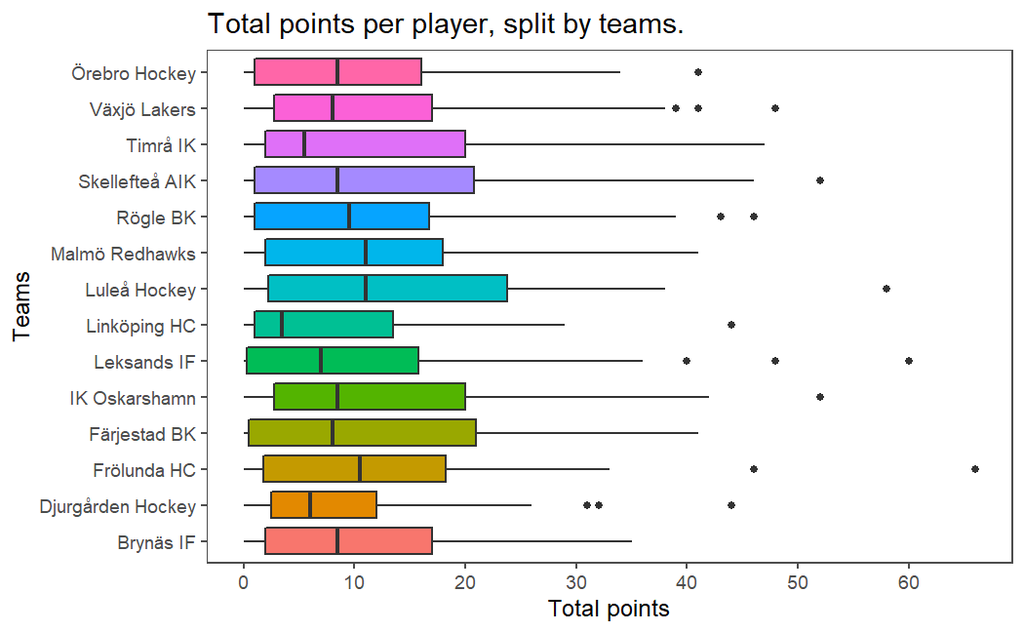

```r
bp <- ggplot(data = df, aes(x = team, y = tp, fill = team)) +
  geom_boxplot() +
  labs(x = 'Teams', y = 'Total points', title = "Total points per player, split by teams.") +
  scale_y_continuous(breaks = seq(0, 400, 10)) +
  coord_flip() +
  theme_few()

bp + theme(legend.position="none")
```

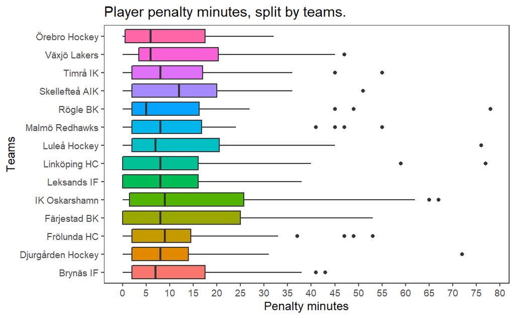

```r
bp <- ggplot(data = df, aes(x = team, y = pim, fill = team)) +
  geom_boxplot() +
  labs(x = 'Teams', y = 'Penalty minutes', title = "Player penalty minutes, split by teams.") +
  scale_y_continuous(breaks = seq(0, 400, 5)) +
  coord_flip() +
  theme_few()

bp + theme(legend.position="none")
```

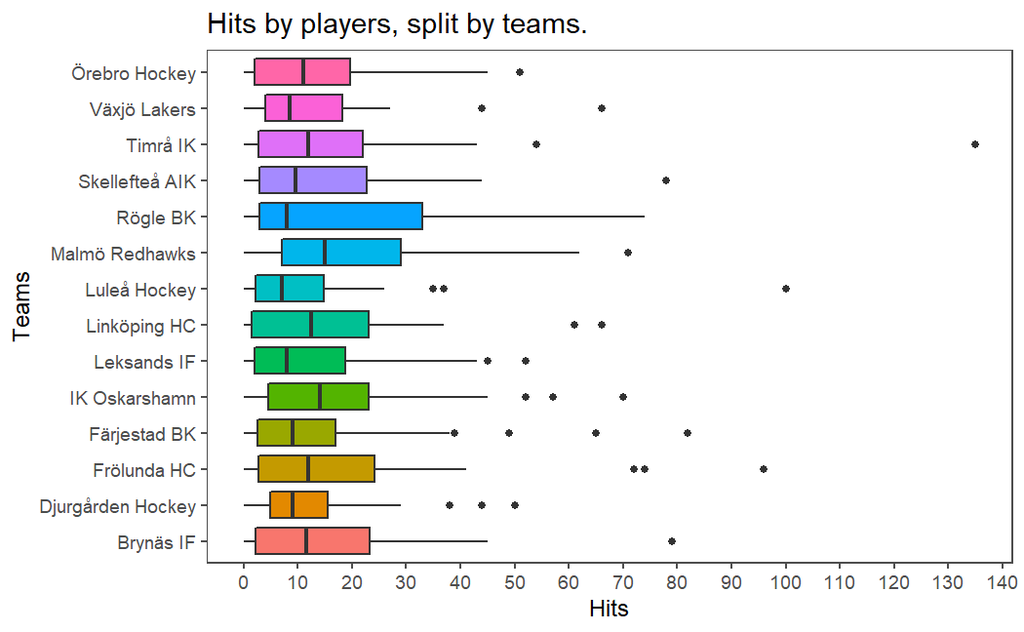

```r
bp <- ggplot(data = df, aes(x = team, y = hits, fill = team)) +
  geom_boxplot() +
  labs(x = 'Teams', y = 'Hits', title = "Hits by players, split by teams.") +
  scale_y_continuous(breaks = seq(0, 400, 10)) +
  coord_flip() +
  theme_few()

bp + theme(legend.position="none")
```

```r
remove(bp) #Dont need this anymore
```

Now it’s time to create a chart that seperates forwards and defenders.

It will show all the relevant quantitative variables, to get a feel for what we can expect from the average defender and forward.

```r
rm_cols <- c('full_name', 'last_name', 'first_name', 'is_on_team', 'team', 'nr')
temp_df <- df[, !(names(df) %in% rm_cols)] #Making a temporary dataframe

l <- c()
l <- as.list(l)
i=1

while(i<length(temp_df)) { #A loop that brings in all relevant data into a list
  b <- c(mean(temp_df[temp_df$pos == "F", i+1]),
                       sd(temp_df[temp_df$pos == "F", i+1]),
                       mean(temp_df[temp_df$pos == "D", i+1]),
                       sd(temp_df[temp_df$pos == "D", i+1]))
  b <- round(b, 2)
  b <- paste(unlist(b), collapse = ' ')
  l <- c(l,b)
  i=i+1
}

l <- as.data.frame(rbind(l))
l <- as.data.frame(t(l)) #Transposing to make columns into rows

l$a <- l$l

library(splitstackshape)
chart_df <- cSplit(l, 'a', ' ') #splits column "a" in l dataframe by space
chart_df$l <- NULL #dont need this anymore

colnames(chart_df) <- c(
  "Forward (Average)",
  "Forward (Standard Deviation)",
  "Defender (Average)",
  "Defender (Standard Deviation)")

chart_df <- as.matrix(chart_df) #making it into a matrix to be able to rename rows.

rownames(chart_df) <- c(
  "Games Played",
  "Goals",
  "Assists",
  "Total Points",
  "Penalty Minutes",
  "Game-Winning Goals",
  "Points Per Game",
  "Shots On Goal",
  "Hits",
  "Blocked Shots",
  "+",
  "-",
  "+/-",
  "TOI/GP (Seconds)")

#Removing stuff i dont need
remove(l)
remove(temp_df)
remove(b)
remove(i)
remove(rm_cols)

chart_df
```

```
                   Forward (Average) Forward (Standard Deviation) Defender (Average)
Games Played                   33.74                        17.89              29.33
Goals                           6.08                         6.19               1.95
Assists                         8.26                         8.88               6.29
Total Points                   14.34                        14.22               8.24
Penalty Minutes                12.43                        14.48              13.20
Game-Winning Goals              1.13                         1.53               0.29
Points Per Game                 1.46                         2.34               0.33
Shots On Goal                  49.02                        41.13              38.09
Hits                           15.28                        16.37              16.94
Blocked Shots                  12.71                        10.53              22.76
+                              16.24                        13.39              17.24
-                              16.87                        12.15              16.93
+/-                            -0.62                         7.72               0.31
TOI/GP (Seconds)              719.70                       332.10             830.06
                   Defender (Standard Deviation)
Games Played                               18.95
Goals                                       2.38
Assists                                     7.40
Total Points                                9.29
Penalty Minutes                            15.53
Game-Winning Goals                          0.64
Points Per Game                             0.90
Shots On Goal                              36.38
Hits                                       21.11
Blocked Shots                              19.50
+                                          14.88
-                                          13.80
+/-                                         7.08
TOI/GP (Seconds)                          423.05
```

```r
#The chart looks good, now It's time to export it as html

print(xtable(chart_df, digits = 2), type = "html", file = "position_differences_chart.html")

remove(chart_df) #Dont need this anymore
```

Now it’s time to plot some different graphs showing differences between forwards and defenders in ggplot2.

I will also perform hypothesis testing to see if the difference is statistically significant.

```r
library(ggplot2)
library(ggthemes)
library(scales)
library(dplyr)
```

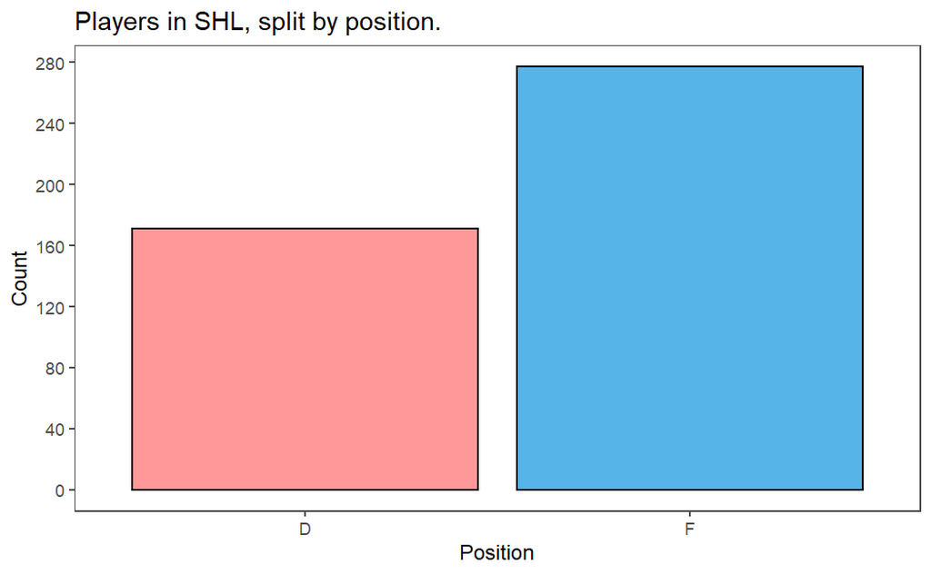

```r
ggplot(data = df, aes(x = pos)) +
  geom_bar(fill=c("#FF9999", "#56B4E9"), colour="black") +
  labs(x = 'Position', y = 'Count', title = "Players in SHL, split by position.") +
  scale_y_continuous(breaks = seq(0, 400, 40)) +
  theme_few()
```

As we can see in the graph above there is more forwards than defenders. This will reflect the graphs i will show further down, but I hope the graphs can give you a feel about the differences between the positions.

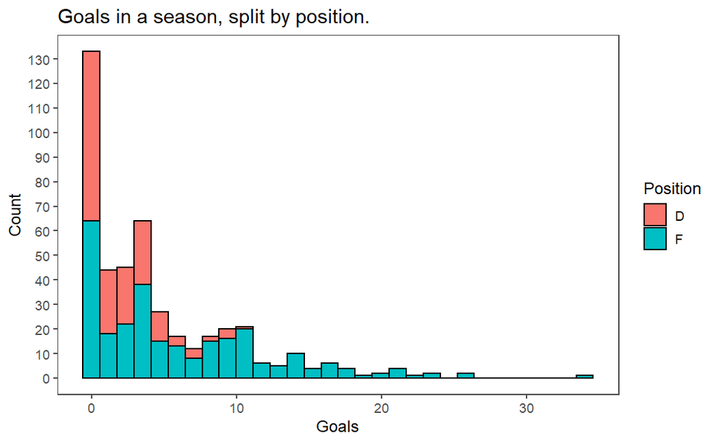

```r
ggplot(data = df, aes(x = g, fill = factor(pos))) +
  geom_histogram(colour="black") +
  labs(x = 'Goals', y = 'Count', title = "Goals in a season, split by position.",
       fill='Position') +
  scale_x_continuous(breaks = seq(0, 50, 10)) +
  scale_y_continuous(breaks = seq(0, 400, 10)) +
  theme_few()
```

In the graph above it seems like a forward score more goals than defenders on average.

I’m gonna test this in a hypothesis test with 5% signficance level. I will use the Bonferroni correction because im gonna do a total of 5 hypothesis tests.

```r
#I'm doing the first hypothesis test manually.

#H0 = (Goals by forwards = Goals by defenders)
#H1 = (Goals by forwards > Goals by defenders)

f_goal_avg <- mean(df$g[df$pos == 'F'])
d_goal_avg <- mean(df$g[df$pos == 'D'])

f_goal_sd <- sd(df$g[df$pos == 'F'])
d_goal_sd <- sd(df$g[df$pos == 'D'])

f_goal_n <- length(df$g[df$pos == 'F'])
d_goal_n <- length(df$g[df$pos == 'D'])

getting_degrees_of_freedom <- t.test(df$g[df$pos == 'F'], df$g[df$pos == 'D'])
degrees_of_freedom <- getting_degrees_of_freedom[[2]][[1]]

t_alpha <- qt(0.99, df = degrees_of_freedom) #One sided hypothesis test, its 0.99 because of the Bonferroni correction

standard_error <- sqrt((f_goal_sd^2)/f_goal_n + (d_goal_sd^2)/d_goal_n)

t_obs <- (f_goal_avg - d_goal_avg - 0)/standard_error

p_value <- pt(-t_obs, degrees_of_freedom)

p_value
```

```
[1] 2.72598e-21
```

```r
t_obs > t_alpha
```

```
[1] TRUE
```

It’s statistically secured that forwards do more goals than defenders in a regular SHL season with a 5% significance level. The null hypothesis is rejected.

```r
#Removing variables i dont need anymore
remove(f_goal_avg)
remove(f_goal_sd)
remove(f_goal_n)
remove(d_goal_avg)
remove(d_goal_sd)
remove(d_goal_n)
remove(getting_degrees_of_freedom)
remove(degrees_of_freedom)
remove(t_alpha)
remove(t_obs)
remove(p_value)
remove(standard_error)
```

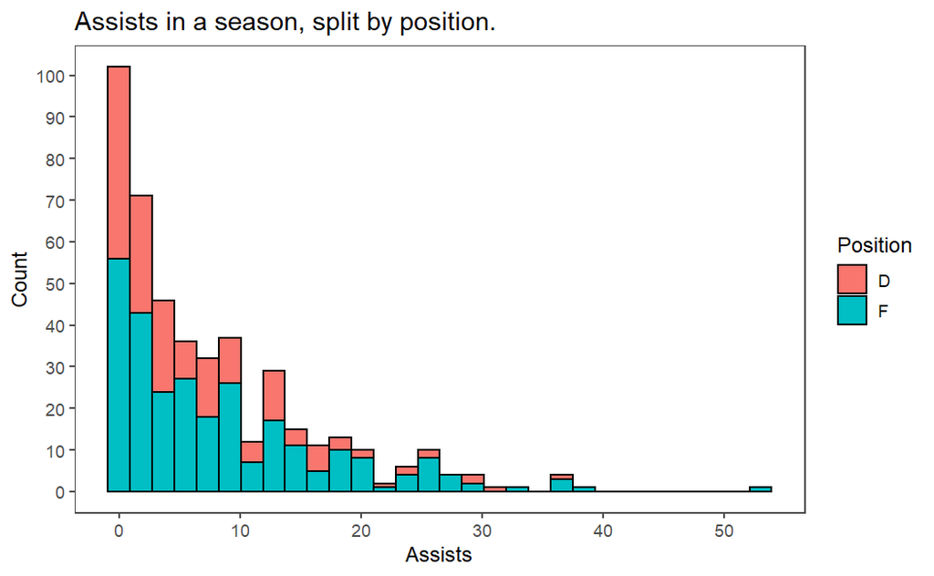

```r
ggplot(data = df, aes(x = a, fill = factor(pos))) +
  geom_histogram(colour="black") +
  labs(x = 'Assists', y = 'Count', title = "Assists in a season, split by position.",
       fill='Position') +
  scale_x_continuous(breaks = seq(0, 50, 10)) +
  scale_y_continuous(breaks = seq(0, 400, 10)) +
  theme_few()
```

In the graph above it seems like a forward also make more assists than defenders on average.

I’m gonna test this in a hypothesis test again with 5% signficance level. I will use the Bonferroni correction because as i wrote before, I’m gonna do a total of 5 hypothesis tests.

```r
#H0 = (Assists by forwards = Assists by defenders)
#H1 = (Assists by forwards > Assists by defenders)

#One sided hypothesis test
t.test(df$a[df$pos == 'F'], df$a[df$pos == 'D'], alternative = "greater")
```

```
    Welch Two Sample t-test

data:  df$a[df$pos == "F"] and df$a[df$pos == "D"]
t = 2.5338, df = 408.03, p-value = 0.005828
alternative hypothesis: true difference in means is greater than 0
95 percent confidence interval:
 0.6881689       Inf
sample estimates:
mean of x mean of y
 8.256318  6.286550
```

p-value of 0.005828 is less than 0.01.

It’s statistically secured that forwards do more assists than defenders in a regular SHL season with a 5% significance level. The null hypothesis is rejected.

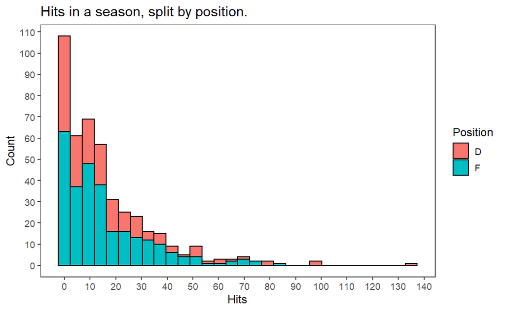

```r
ggplot(data = df, aes(x = hits, fill = factor(pos))) +
  geom_histogram(colour="black") +
  labs(x = 'Hits', y = 'Count', title = "Hits in a season, split by position.",
       fill='Position') +
  scale_x_continuous(breaks = seq(0, 200, 10)) +
  scale_y_continuous(breaks = seq(0, 200, 10)) +
  theme_few()
```

Here it doesnt seem to be much of a difference between the positions in hits.

I’m again gonna do a hypothesis test to see if there is any difference between the positions here.

```r
#H0 = (Hits by forwards = Hits by defenders)
#H1 = (Hits by forwards != Hits by defenders)

#two sided hypothesis test
t.test(df$hits[df$pos == 'F'], df$hits[df$pos == 'D'], alternative = "two.sided")
```

```
    Welch Two Sample t-test

data:  df$hits[df$pos == "F"] and df$hits[df$pos == "D"]
t = -0.87508, df = 294.58, p-value = 0.3822
alternative hypothesis: true difference in means is not equal to 0
95 percent confidence interval:
 -5.374130  2.065962
sample estimates:
mean of x mean of y
 15.28159  16.93567
```

p-value of 0.3822 is larger than 0.01.

The null hypothesis is accepted.

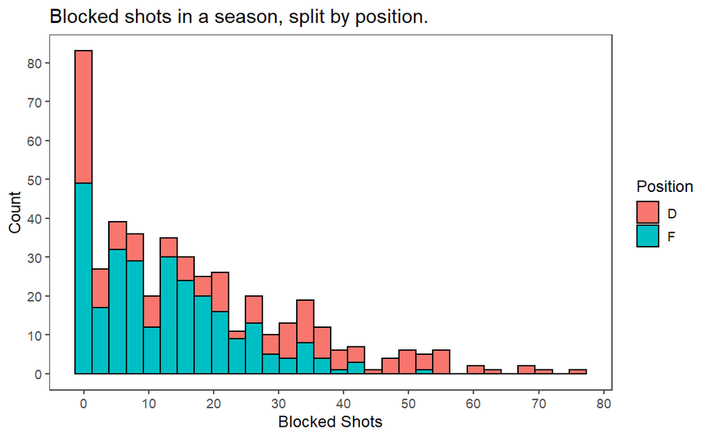

```r
ggplot(data = df, aes(x = bks, fill = factor(pos))) +
  geom_histogram(colour="black") +
  labs(x = 'Blocked Shots', y = 'Count', title = "Blocked shots in a season, split by position.",
       fill='Position') +
  scale_x_continuous(breaks = seq(0, 200, 10)) +
  scale_y_continuous(breaks = seq(0, 400, 10)) +
  theme_few()
```

Here it seems like the defender is blocking more shots than forwards. Let’s see if the difference is statistically significant!

```r
#H0 = (Blocked shots by forwards = Blocked shots by defenders)
#H1 = (Blocked shots by forwards < Blocked shots by defenders)

#one sided sided hypothesis test
t.test(df$bks[df$pos == 'F'], df$bks[df$pos == 'D'], alternative = "less")
```

```
    Welch Two Sample t-test

data:  df$bks[df$pos == "F"] and df$bks[df$pos == "D"]
t = -6.205, df = 232.03, p-value = 1.245e-09
alternative hypothesis: true difference in means is less than 0
95 percent confidence interval:
      -Inf -7.377149
sample estimates:
mean of x mean of y
 12.70758  22.76023
```

p-value of 1.245e-09 is less than 0.01. The null hypothesis is rejected.

It’s statistically secured that defenders blocks more shots than forwards in a regular SHL season with a 5% signficance level.

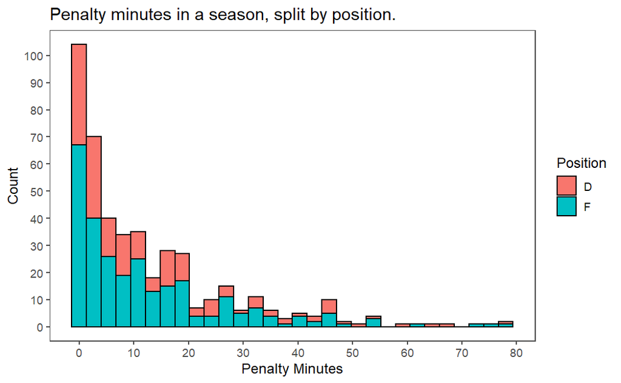

```r
ggplot(data = df, aes(x = pim, fill = factor(pos))) +
  geom_histogram(colour="black") +
  labs(x = 'Penalty Minutes', y = 'Count', title = "Penalty minutes in a season, split by position.",
       fill='Position') +
  scale_x_continuous(breaks = seq(0, 200, 10)) +
  scale_y_continuous(breaks = seq(0, 400, 10)) +
  theme_few()
```

Here it doesnt seem to be much of a difference, lets see what a hypothesis test says!

```r
#H0 = (Penalty minutes for forwards = Penalty minutes for defenders)
#H1 = (Penalty minutes for forwards != Penalty minutes for defenders)

#one sided sided hypothesis test
t.test(df$pim[df$pos == 'F'], df$pim[df$pos == 'D'], alternative = "two.sided")
```

```
    Welch Two Sample t-test

data:  df$pim[df$pos == "F"] and df$pim[df$pos == "D"]
t = -0.51996, df = 340.85, p-value = 0.6034
alternative hypothesis: true difference in means is not equal to 0
95 percent confidence interval:
 -3.661860  2.130625
sample estimates:
mean of x mean of y
 12.43321  13.19883
```

p-value of 0.6034 is larger than 0.01. The null hypothesis is accepted.

Could there be a correlation between penalty minutes and hits?

```r
cor(df$hits, df$pim, method = 'pearson')
```

```
[1] 0.5380336
```

There is an positive correlation between how many hits a player does and how many penalty minutes they get.

Let’s see how this looks in a linear regression model!

```r
ols_model <- lm(pim ~ hits, data =df)

summary(ols_model)
```

```
Call:
lm(formula = pim ~ hits, data = df)

Residuals:
    Min      1Q  Median      3Q     Max
-54.771  -6.208  -4.326   3.899  59.429

Coefficients:
            Estimate Std. Error t value Pr(>|t|)
(Intercept)  5.77090    0.78616   7.341 1.02e-12 ***
hits         0.43704    0.03242  13.480  < 2e-16 ***
---
Signif. codes:  0 ‘***’ 0.001 ‘**’ 0.01 ‘*’ 0.05 ‘.’ 0.1 ‘ ’ 1

Residual standard error: 12.56 on 446 degrees of freedom
Multiple R-squared:  0.2895,    Adjusted R-squared:  0.2879
F-statistic: 181.7 on 1 and 446 DF,  p-value: < 2.2e-16
```

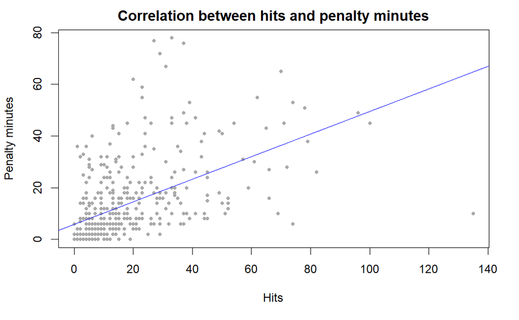

```r
plot(df$hits, df$pim, xlab = "Hits", ylab = "Penalty minutes", col = "darkgrey",
     main = "Correlation between hits and penalty minutes", type="p", pch = 20)
abline(ols_model, col = "blue")
```

According to my linear regression model, per hit a player does they will get 0.437 penalty minutes on average.

It also says that 28.95% of the penalty minutes a player gets in a season can be explained by how many hits they are doing per season.

That could be something to think about for the SHL teams, if they want someone that does alot of hits, they should know that will give them more penalty minutes as a team aswell.

They should think over this and see if it’s worth it signing a player because he is doing alot of hits.

Thank you for checking out my project!